# BsAbunance

zagor

2025-11-26

```r
rm(list = ls(all = TRUE))
gc()
```

```
##           used (Mb) gc trigger (Mb) max used (Mb)
## Ncells  617278 33.0    1420060 75.9   686457 36.7
## Vcells 1158607  8.9    8388608 64.0  1877216 14.4
```

# 1 Notes

- Multiple genotypes and unequal group sizes
- Each plant contributes multiple observations -> complex tissue structure
- Binary outcome
- Fixed effects: Genotype, Tissue (Genotype * tissue part (interaction))
- Random effects: Plant nested within Genotype (1 | Genotype/plant)
- Binomial outcome

# 2 Bayesian generalized linear models with group-specific terms via Stan

- [rstanarm GitHub](https://github.com/stan-dev/rstanarm)
- [vignette](https://mc-stan.org/rstanarm/articles/rstanarm.html)

## 2.1 MCMC diagnostics

- random effect-level variation : Sigma
- large and positive effect -> strongly increases the probability of output = 1 (mean, sd, … cols)
- Rhat ≈ 1.0 : Chains converged perfectly, Rhat ≈ 1.0; Rhat > 1.1: problematic
- n_eff - higher is better (ideally > 1000); >1500 : Effective sample size is strong
- mcse ~ 0.0 : Monte Carlo error is negligible

## 2.2 indices relevant to describe and characterize the posterior distribution

- pd: Probability of Direction — the probability the effect is strictly positive or negative
- ROPE Region of Practical Equivalence — a range around zero considered ‘negligible’
- % in ROPE - Percentage of the posterior within the ROPE — higher means the effect is likely trivial

# 3 packages

```r
library(magrittr)
library(data.table)
library(ggplot2)
```

# 4 Bs Abundance L6

```r
fp = file.path('..', 'input')

fn = 'Table_combinedInputs.xlsx'
wb = openxlsx::loadWorkbook(file.path(fp, fn))
sheet_names = names(wb)
sheet_name = grep("BsAbundance_L6", sheet_names, value = TRUE)

dt = openxlsx::read.xlsx(file.path(fp, fn), sheet = sheet_name, startRow = 10)
empty_col_index = which(names(dt) == "")[1]
# subset to columns before the first empty one
if (!is.na(empty_col_index)) {
  dt = dt[, 1:(empty_col_index - 1)]
}

setDT(dt)
dt[, Sample.ID := NULL]
table(dt$Strain)
```

```
##
## PS-218
##     41
```

```r
table(dt$Treatment)
```

```
##
##    inoculated noninoculated
##            41            11
```

## 4.1 inoculated

```r
inn = dt[dt$Treatment == 'inoculated', ]

inn$output = NA
inn$`Positive/Negative.sample` = trimws(inn$`Positive/Negative.sample`)
inn$output[inn$`Positive/Negative.sample` == '+'] = 1
inn$output[inn$`Positive/Negative.sample` == '-'] = 0

inn = inn[grep('apex', inn$Tissue, invert = TRUE), ]


table(inn$Tissue, inn$output)
```

```
##
##                                          0 1
##   1st leaf                               0 3
##   1st node & 2nd node & internoed & leaf 0 1
##   1st node & internode                   0 3
##   1st node & internode & leaf            0 2
##   2nd node & internode                   0 1
##   2nd node & internode & leaf            1 4
##   3rd leaf                               0 2
##   3rd node & internode                   0 1
##   3rd node & internode & leaf            2 3
##   4th node & internode & leaf            1 4
```

```r
inn$part = gsub(' .*', '', inn$Tissue)
table(inn$part, inn$output, inn$Genotype)
```

```
## , ,  = Rywal
##
##
##       0 1
##   1st 0 4
##   2nd 1 2
##   3rd 2 1
##   4th 1 2
##
## , ,  = shPTI5-Rywal L6
##
##
##       0 1
##   1st 0 5
##   2nd 0 3
##   3rd 0 5
##   4th 0 2
```

```r
inn$plant = sub('P', '', inn$Plant.No)

table(inn$Genotype, inn$part)
```

```
##
##                   1st 2nd 3rd 4th
##   Rywal             6   4   4   3
##   shPTI5-Rywal L6   6   3   5   2
```

```r
table(inn$Genotype, inn$plant)
```

```
##
##                   1 2 3 4
##   Rywal           4 5 5 3
##   shPTI5-Rywal L6 6 5 4 1
```

```r
inn = inn[, .SD, .SDcols = grep("Genotype|output|part|plant$", names(inn), ignore.case = TRUE)]

inn$Genotype = as.factor(inn$Genotype)
inn$part = as.factor(inn$part)
inn$plant = as.factor(inn$plant)

inn = inn[!is.na(inn$output), ]
```

## 4.2 plot counts

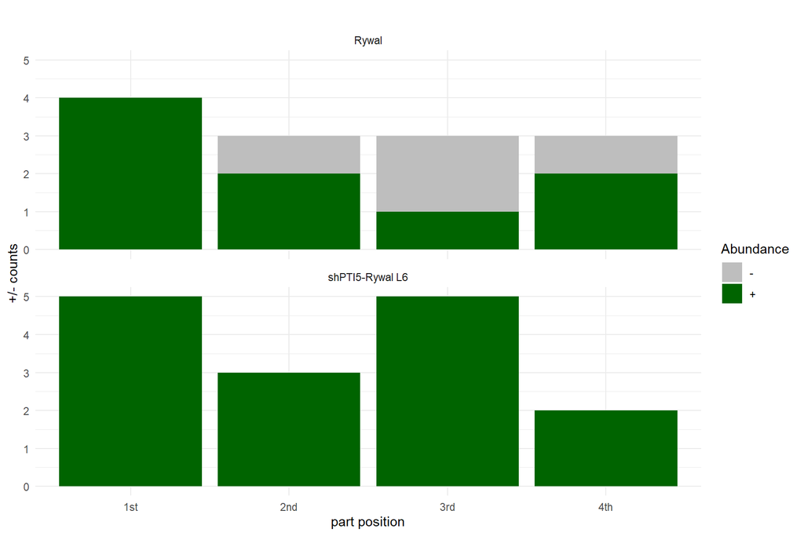

```r
plot_data = inn %>%
  dplyr::filter(!is.na(output)) %>%
  dplyr::group_by(Genotype, part, output) %>%
  dplyr::summarise(count = dplyr::n(), .groups = "drop")

plot_data$output = factor(plot_data$output, levels = c(0, 1), labels = c("-", "+"))

ggplot(plot_data, aes(x = part, y = count, fill = output)) +
  geom_bar(stat = "identity", position = "stack") +
  facet_wrap(~ Genotype, ncol = 1) +
  labs(title = "",
       x = "part position",
       y = "+/- counts",
       fill = "Abundance") +
  theme_minimal() +
  scale_fill_manual(values = c('grey', 'darkgreen'))
```

## 4.3 Bayesian generalized linear models with group-specific terms via Stan

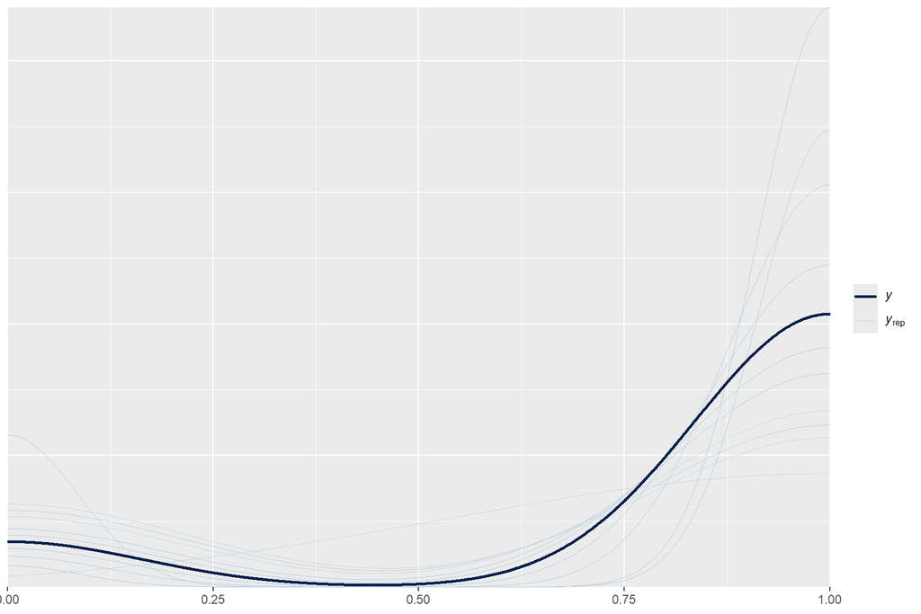

```r
set.seed(123456)

inn$part = relevel(inn$part, ref = "1st")  # changes reference level


model1 = rstanarm::stan_glmer(
  output ~ 0 + Genotype * part + (1 | Genotype/plant),
  data = inn,
  family = binomial(),
  chains = 10,  # default is 4
  iter = 1000,
  seed = 123456,
  control = list(adapt_delta = 0.99, max_treedepth = 15)
)
model2 = rstanarm::stan_glmer(
  output ~ 0 + Genotype * part + (1 | Genotype/plant) + (1 | Genotype:plant:part),
  data = inn,
  family = binomial(),
  chains = 10,  # default is 4
  iter = 1000,
  seed = 123456,
  control = list(adapt_delta = 0.99, max_treedepth = 15)
)
model3 = rstanarm::stan_glmer(
  output ~ 0 + Genotype + (1 | Genotype:plant:part),
  data = inn,
  family = binomial(),
  chains = 10,  # default is 4
  iter = 1000,
  seed = 123456,
  control = list(adapt_delta = 0.99, max_treedepth = 15)
)
rstanarm::pp_check(model1)
```

```r
mean(rstanarm::bayes_R2(model1))
```

```
## [1] 0.4390742
```

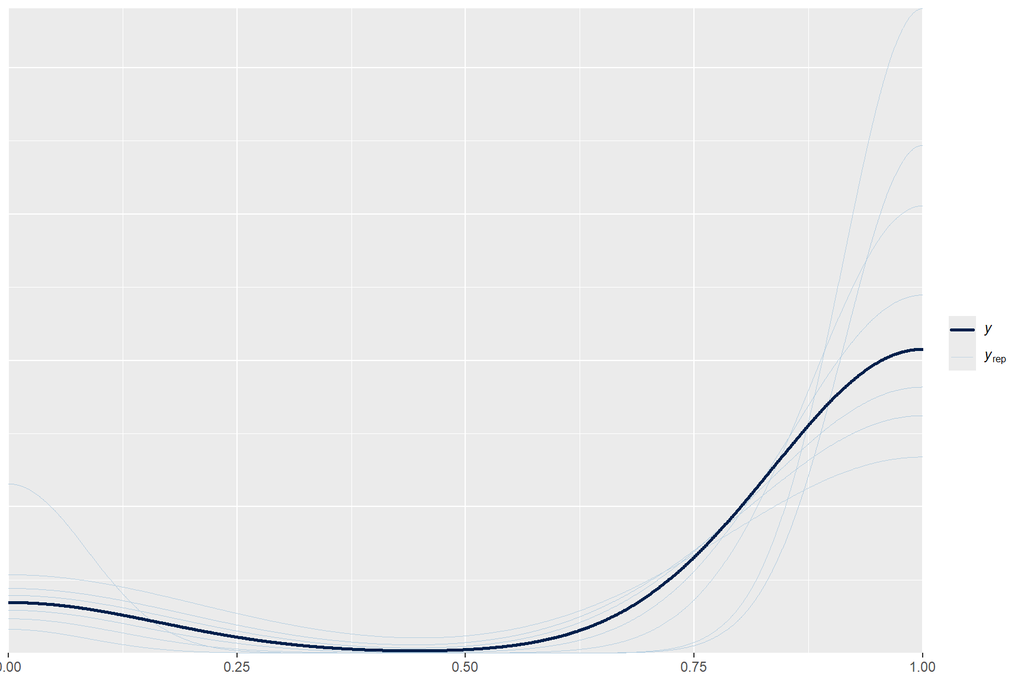

```r
rstanarm::pp_check(model2)
```

```r
mean(rstanarm::bayes_R2(model2))
```

```
## [1] 0.5203623
```

[figure not shown]

```r
rstanarm::pp_check(model3)
```

```r
mean(rstanarm::bayes_R2(model3))
```

```
## [1] 0.3051563
```

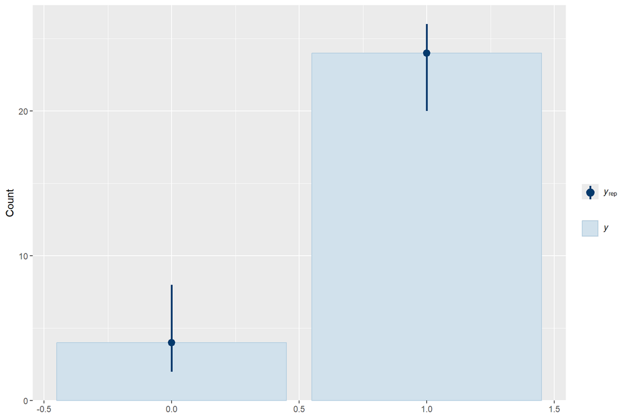

```r
# Compares the distribution of observed outcomes (y) to the distribution of simulated outcomes (yrep)
yrep = rstanarm::posterior_predict(model2)

# Uses bar plots to show how often each outcome (0 or 1) occurs
bayesplot::ppc_bars(y = inn$output, yrep = yrep) # Bar plot of observed vs predicted
```

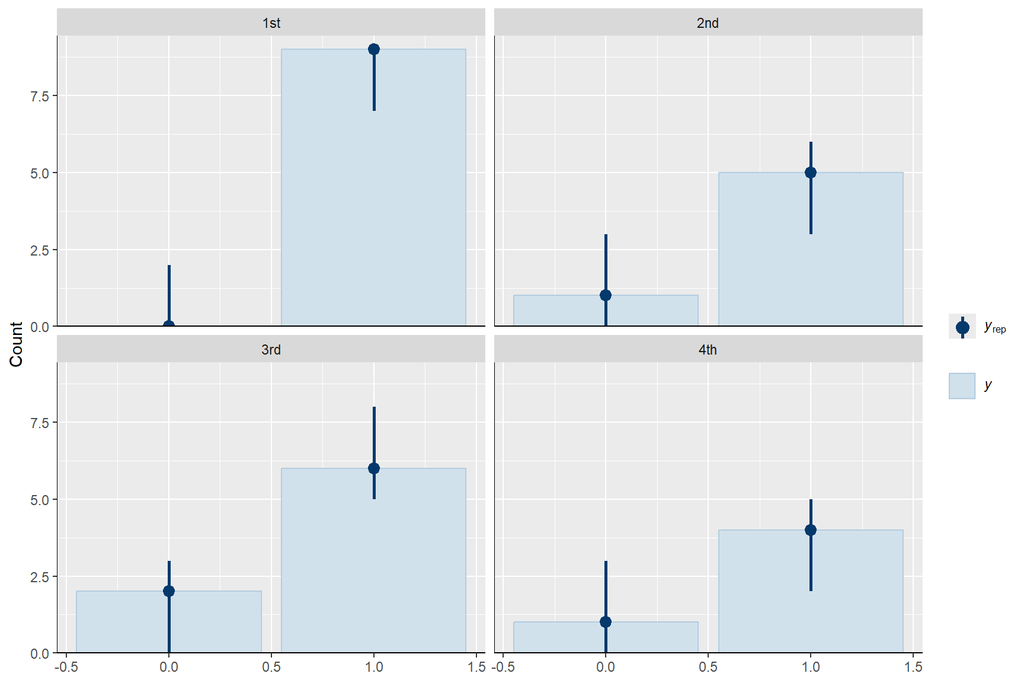

```r
# bayesplot::ppc_dens_overlay(y = inn$output, yrep = yrep)  # Density overlay
bayesplot::ppc_bars_grouped(y = inn$output, yrep = yrep, group = inn$part)
```

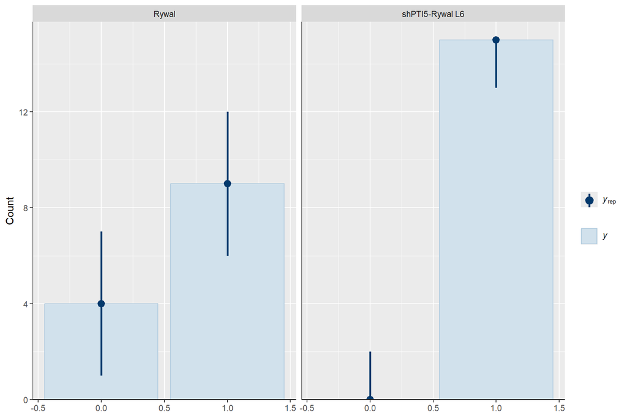

```r
bayesplot::ppc_bars_grouped(y = inn$output, yrep = yrep, group = inn$Genotype)
```

```r
# Compute a Bayesian version of R-squared for regression models
r2_samples = rstanarm::bayes_R2(model2)
# On average,  model explains about XY% of the variance in the binary outcome
mean(r2_samples)  # Average R² across posterior
```

```
## [1] 0.5203623
```

```r
# 95% Credible Interval
quantile(r2_samples, probs = c(0.025, 0.975))  # 95% credible interval
```

```
##      2.5%     97.5%
## 0.2024485 0.8031177
```

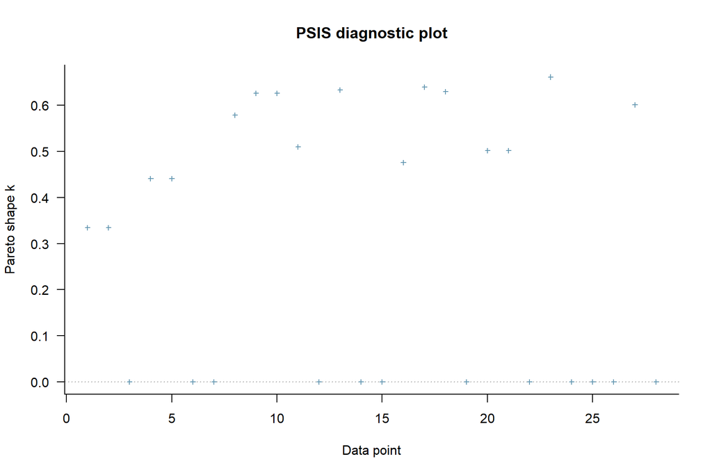

```r
# Cross-Validation
# Pareto k diagnostics measure how well the importance sampling works for each observation
# Values:
#   k < 0.5 : good
#   0.5 < k < 0.7 : okay
#   k > 0.7 : problematic
#   k > 1 : very problematic
# observations with Pareto k>0.7 are influential and may distort the reliability of your Leave-One-Out (LOO) cross-validation estimates
loo_result = loo::loo(model2, k_threshold = 0.7)
# print(loo_result)
plot(loo_result)
```

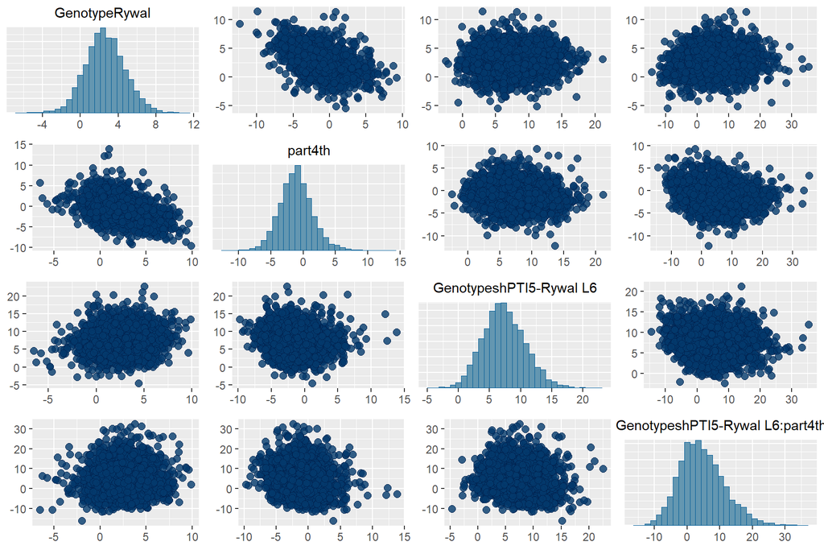

```r
# pk = loo::pareto_k_values(loo_result)
# inn[which(pk > 0.7), ]

# extracting the combined posterior samples across all chains
posterior = as.matrix(model2)
# all
posterior_array = as.array(model2)

# colnames(posterior)
bayesplot::mcmc_pairs(
  posterior_array,
  pars = c(
    "GenotypeRywal",
    "part4th",
    "GenotypeshPTI5-Rywal L6",
    "GenotypeshPTI5-Rywal L6:part4th"
  )
)
```

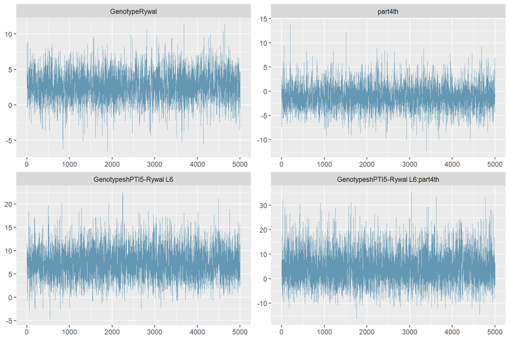

```r
bayesplot::mcmc_trace(posterior, pars = c("GenotypeRywal","part4th",
                                          "GenotypeshPTI5-Rywal L6", "GenotypeshPTI5-Rywal L6:part4th"))
```

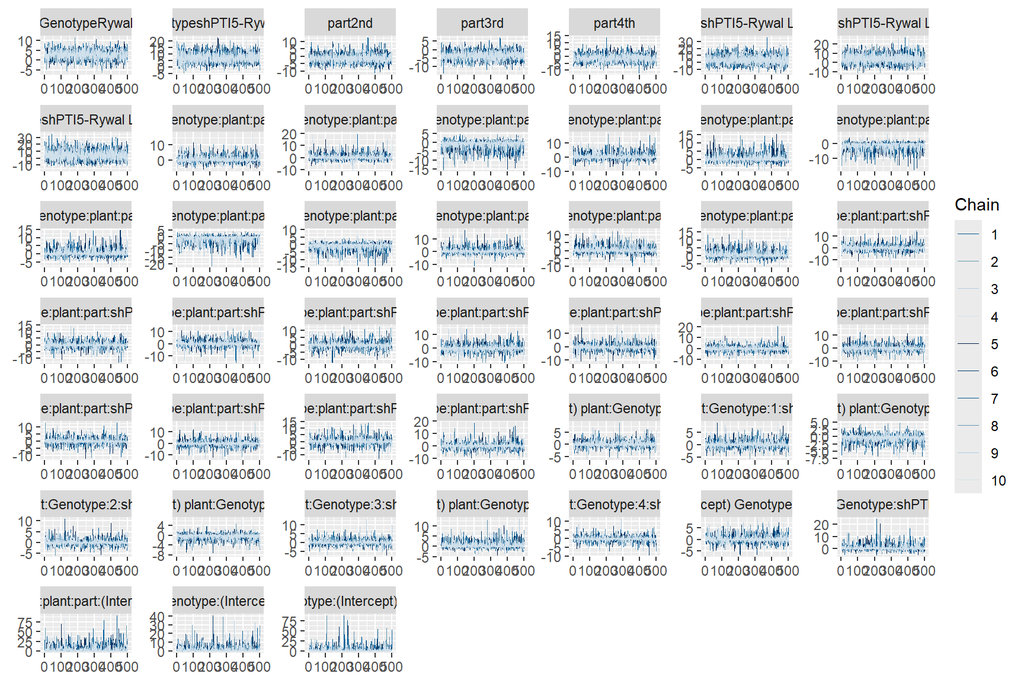

```r
# Each line represents one MCMC chain sampling a parameter
# The x-axis is the iteration number; the y-axis is the sampled value
plot(model2, plotfun = "trace")
```

```r
summary(model2)  # Should be close to 1
```

```
##
## Model Info:
##  function:     stan_glmer
##  family:       binomial [logit]
##  formula:      output ~ 0 + Genotype * part + (1 | Genotype/plant) + (1 | Genotype:plant:part)
##  algorithm:    sampling
##  sample:       5000 (posterior sample size)
##  priors:       see help('prior_summary')
##  observations: 28
##  groups:       Genotype:plant:part (24), plant:Genotype (8), Genotype (2)
##
## Estimates:
##                                                            mean   sd   10%
## GenotypeRywal                                             2.6    2.1  0.0
## GenotypeshPTI5-Rywal L6                                   7.4    3.4  3.1
## part2nd                                                  -1.2    2.6 -4.4
## part3rd                                                  -3.4    2.5 -6.5
## part4th                                                  -1.1    2.6 -4.2
## GenotypeshPTI5-Rywal L6:part2nd                           3.9    6.0 -3.3
## GenotypeshPTI5-Rywal L6:part3rd                           4.2    4.9 -1.8
## GenotypeshPTI5-Rywal L6:part4th                           4.6    6.9 -3.6
## b[(Intercept) Genotype:plant:part:Rywal:1:1st]            0.4    1.8 -1.1
## b[(Intercept) Genotype:plant:part:Rywal:1:2nd]            0.5    1.8 -1.0
## b[(Intercept) Genotype:plant:part:Rywal:1:3rd]           -0.9    2.0 -3.4
## b[(Intercept) Genotype:plant:part:Rywal:1:4th]            0.6    1.9 -0.9
## b[(Intercept) Genotype:plant:part:Rywal:2:1st]            0.7    1.9 -0.8
## b[(Intercept) Genotype:plant:part:Rywal:2:4th]           -1.3    2.2 -4.1
## b[(Intercept) Genotype:plant:part:Rywal:3:1st]            0.5    1.8 -1.0
## b[(Intercept) Genotype:plant:part:Rywal:3:2nd]           -1.3    2.3 -4.3
## b[(Intercept) Genotype:plant:part:Rywal:3:3rd]           -0.8    1.9 -3.0
## b[(Intercept) Genotype:plant:part:Rywal:3:4th]            0.6    1.8 -0.9
## b[(Intercept) Genotype:plant:part:Rywal:4:2nd]            0.5    1.8 -1.0
## b[(Intercept) Genotype:plant:part:Rywal:4:3rd]            0.9    1.9 -0.6
## b[(Intercept) Genotype:plant:part:shPTI5-Rywal_L6:1:1st]  0.1    1.8 -1.7
## b[(Intercept) Genotype:plant:part:shPTI5-Rywal_L6:1:2nd]  0.1    1.9 -1.7
## b[(Intercept) Genotype:plant:part:shPTI5-Rywal_L6:1:3rd]  0.2    1.9 -1.6
## b[(Intercept) Genotype:plant:part:shPTI5-Rywal_L6:1:4th]  0.1    1.9 -1.7
## b[(Intercept) Genotype:plant:part:shPTI5-Rywal_L6:2:1st]  0.1    1.9 -1.7
## b[(Intercept) Genotype:plant:part:shPTI5-Rywal_L6:2:2nd]  0.0    1.9 -1.8
## b[(Intercept) Genotype:plant:part:shPTI5-Rywal_L6:2:3rd]  0.2    1.9 -1.6
```

[output cut: 107 more lines]

```
## b[(Intercept) plant:Genotype:2:Rywal]                    0.0  1.0  4627
## b[(Intercept) plant:Genotype:2:shPTI5-Rywal_L6]          0.0  1.0  5103
## b[(Intercept) plant:Genotype:3:Rywal]                    0.0  1.0  4457
## b[(Intercept) plant:Genotype:3:shPTI5-Rywal_L6]          0.0  1.0  4689
## b[(Intercept) plant:Genotype:4:Rywal]                    0.0  1.0  4366
## b[(Intercept) plant:Genotype:4:shPTI5-Rywal_L6]          0.0  1.0  4851
## b[(Intercept) Genotype:Rywal]                            0.0  1.0  3264
## b[(Intercept) Genotype:shPTI5-Rywal_L6]                  0.0  1.0  3233
## Sigma[Genotype:plant:part:(Intercept),(Intercept)]       0.1  1.0  2580
## Sigma[plant:Genotype:(Intercept),(Intercept)]            0.0  1.0  4361
## Sigma[Genotype:(Intercept),(Intercept)]                  0.1  1.0  3895
## mean_PPD                                                 0.0  1.0  4831
## log-posterior                                            0.1  1.0  1817
##
## For each parameter, mcse is Monte Carlo standard error, n_eff is a crude measure of effective sample size, and Rhat is the potential scale reduction factor on split chains (at convergence Rhat=1).
```